# Python数据处理

## 13. scikit-learn

主讲人：丁平尖

## scikit-learn

- 一个开源的Python机器学习库
- 基于numpy、scipy和matplotlib构建
- 使许多常见的机器学习/统计模型易于使用
- API支持简单的模型拟合、预测、交叉验证等
- 安装：
  - `pip install scikit-learn`
  - `conda install scikit-learn`

## 示例：scikit-learn中的分类器

- sklearn包含许多内置数据集，其中之一是著名的MNIST数字数据集的版本。

```python
import warnings
warnings.filterwarnings('ignore')
from sklearn import datasets
digits = datasets.load_digits()
print(type(digits))
# sklearn.utils._bunch.Bunch 是一个在 Scikit-learn 库中使用的类，
# 主要用于将多个属性组合在一起，类似于一个字典，
# 但它允许使用点（.）来访问属性而不是使用方括号（[]）。
print(digits.keys())
print(digits.target)
```

```
<class 'sklearn.utils._bunch.Bunch'>
dict_keys(['data', 'target', 'frame', 'feature_names', 'target_names', 'images', 'DESCR'])
[0 1 2 ... 8 9 8]
```

- digits.data是一个数组，其条目是64维向量，对应于图像。要显示它们，我们必须将它们重塑为8x8。cmap参数指定颜色映射。

```
(64,)
```

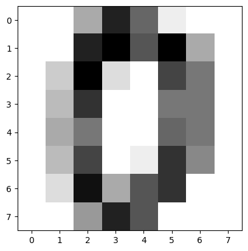

```python
import matplotlib.pyplot as plt
import numpy as np
print(digits.data[0].shape)
plt.imshow(np.reshape(digits.images[0], (8,8)), cmap=plt.cm.gray_r)
```

## 示例：scikit-learn中的分类器

- SVC是一个支持向量机（SVM）分类器，是sklearn提供的许多分类器之一。
- 每个分类器对象都支持fit方法，该方法接受观察值和标签，并调整模型参数以最好地拟合这些数据。
- 我们正在训练除了第一个数字之外的所有数字，保留第一个作为“保留”数据，我们可以在其上测试我们的分类器。

## 支持向量机（Support Vector Machine, SVM） 算法原理

- 从几何角度，对于线性可分数据集，支持向量机就是找距离正负样本都最远的超平面，其解是唯一的，且不偏不倚，**泛化性能更好**。
- 考虑两个独立变量x1和x2，以及一个因变量，用蓝色圆圈或红色圆圈表示。
  - 在这种情况下，超平面是一条线，因为我们正在处理两个特征（x1和x2）。
  - 有多条线（或超平面）可以分隔数据点。
  - 挑战在于确定最大化红色和蓝色圆圈之间分离边缘的最佳超平面。

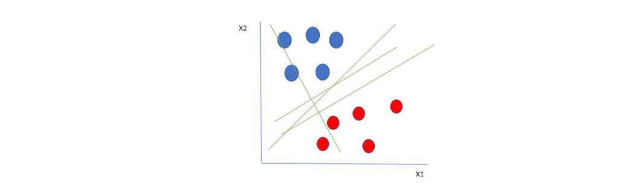

## 支持向量机算法如何工作？

- 支持向量机 (SVM)中最佳超平面的一个合理选择是最大化两个类之间的分离边距。最大边距超平面（也称为硬边距）的选择基于最大化超平面与每侧最近数据点之间的距离。

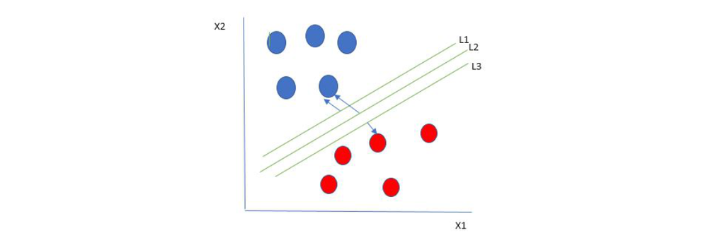

## 数据不是线性可分

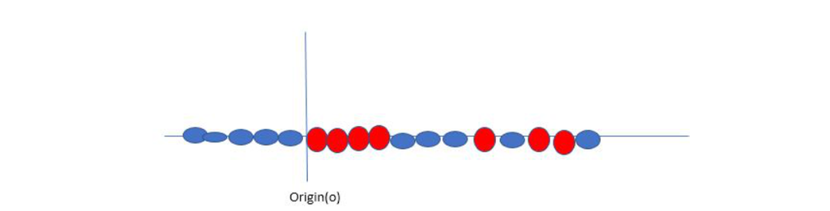

## 数据不是线性可分

- SVM 通过使用核创建一个新变量来解决这个问题。我们将点称为线上的xi ，并创建一个新变量yi作为与原点的距离的函数。

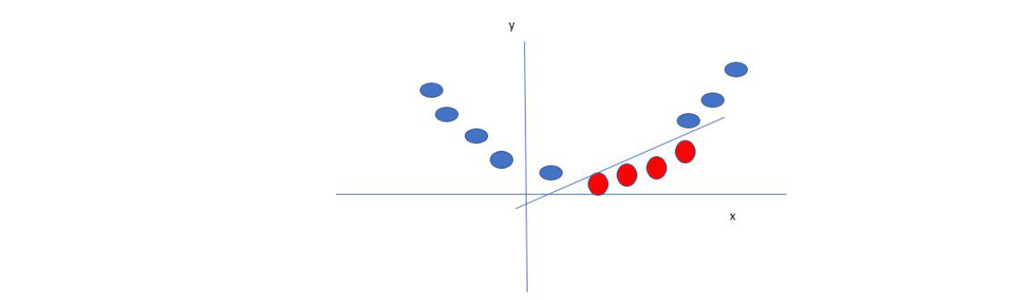

```python
from sklearn import svm
# equation of rbf kernel(径向基函数): K(x, y) = exp(-gamma ||x-y||^2)
# gamma is the parameter for the RBF kernel, C is the regularization parameter
clf = svm.SVC(kernel='rbf', gamma=0.001, C=100.)
clf.fit(digits.data[1:], digits.target[1:])
```

```
SVC(C=100.0, gamma=0.001)
```

- 每个分类器对象还支持predict方法，该方法接受一个观察值，并尝试根据模型参数猜测其“最佳”标签。

```python
clf.predict(digits.data[0:1])
```

```
array([0])
```

## 有监督学习示例：sklearn中的LASSO

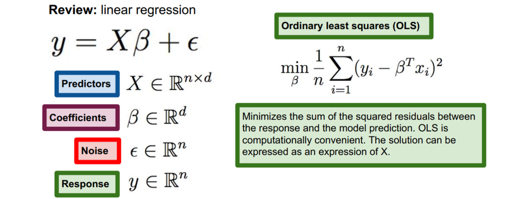

## 有监督学习示例：sklearn中的LASSO

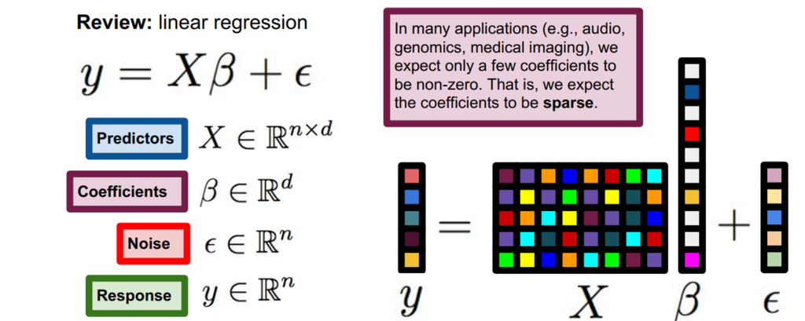

## 有监督学习示例：sklearn中的LASSO

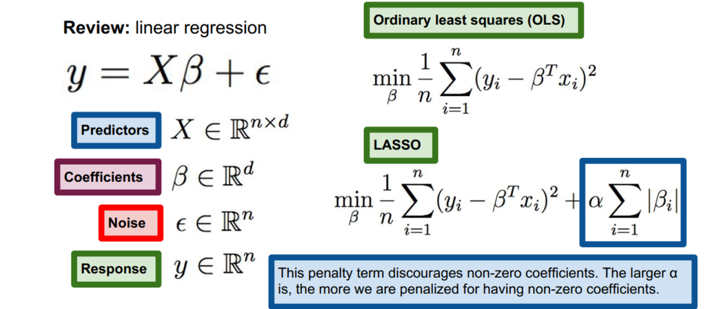

## 有监督学习示例：sklearn中的LASSO

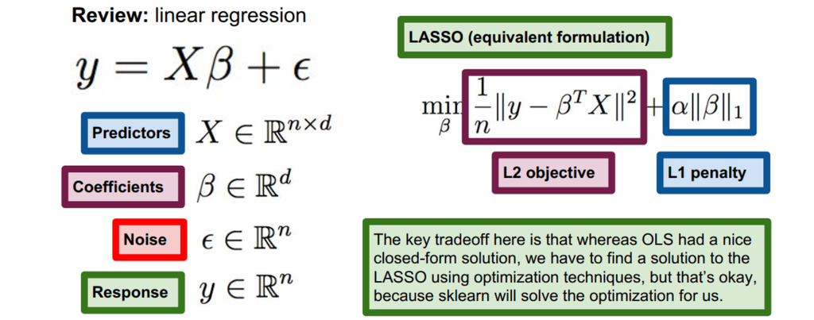

## 有监督学习示例：sklearn中的LASSO

- 生成数据；分割为训练/测试集。
- 基于训练集拟合模型。
- 评估模型在测试数据上的拟合程度。

```python
# 生成数据；
# 200个点在500维空间中。稀疏度k=10。
(n_sample, dim, k) = (200, 500, 10)
X = np.random.randn(n_sample, dim)
beta = np.zeros(dim)
inds = np.random.choice(np.arange(dim), k, replace=False)
beta[inds] = 5 * np.random.randn(k)
y = np.dot(X, beta) + 0.1 * np.random.randn(n_sample)
```

```python
# 分割为训练/测试集。
X_train, y_train = X[:(n_sample // 2)], y[:(n_sample // 2)]
X_test, y_test = X[(n_sample // 2):], y[(n_sample // 2):]

# 基于训练集拟合模型。
from sklearn.linear_model import Lasso
# alpha参数控制我们使用的正则化程度。
lasso = Lasso(alpha=0.1)
# 调用了fit，lasso的系数已经被更新以拟合训练数据
lasso.fit(X_train, y_train)

# make predictions on the test set
y_pred_lasso = lasso.predict(X_test)
from sklearn.metrics import r2_score
# 评估模型在测试数据上的拟合程度。
# 这里的r2_score是R-squared，越接近1越好。
# equation of r2_score: 1 - (sum((y_test - y_pred) ** 2) / sum((y_test - y_test.mean()) ** 2))
r2_score_lasso = r2_score(y_test, y_pred_lasso)
r2_score_lasso
```

```
0.9990104863110415
```

```python
np.where(beta != 0)
```

```
(array([  0,   3,  35,  49, 175, 190, 198, 331, 366, 391], dtype=int64),)
```

```python
# 对目标变量有影响的输入特征
np.where(lasso.coef_!= 0)
```

```
(array([  0,   3,  35,  49,  98, 143, 175, 190, 198, 275, 316, 331, 366,
        391], dtype=int64),)
```

```python
from sklearn.metrics import  f1_score
# equation of f1_score is: 2 * (precision * recall) / (precision + recall)
f1_score(lasso.coef_!=0, beta!=0, average='binary')
```

```
0.8333333333333334
```

## 无监督学习示例：sklearn中的k-GMM

- GMM 的运行原理是，复杂的多峰分布可以通过多个较简单的高斯分布的组合来近似，每个高斯分布代表数据中的不同聚类。
- GMM 能够计算每个数据点属于特定聚类的概率。

```python
import pandas as pd
import seaborn as sns
# 著名的iris数据集。显然数据中存在聚类结构。
# 如何在不使用标签信息的情况下发现它？
iris = datasets.load_iris()
x = iris.data
y = iris.target
y_new = np.array(['setosa' if i == 0 else 'versicolor' if i == 1 else 'virginica' for i in iris.target])

sepal_ratio = x[:,0]/x[:,1] # 萼片的长度除以萼片的宽度
petal_ratio = x[:,2]/x[:,3] # 花瓣的长度除以花瓣的宽度
data = pd.DataFrame({'Sepal Ratio': sepal_ratio, 'Petal Ratio': petal_ratio, 'Class': y_new})
```

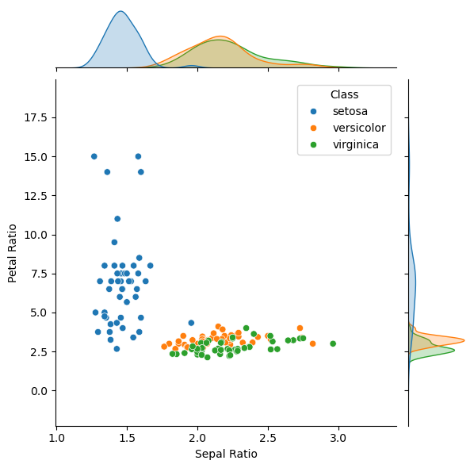

```python
plt1 = sns.jointplot(data=data, x="Sepal Ratio", y="Petal Ratio", hue="Class")
```

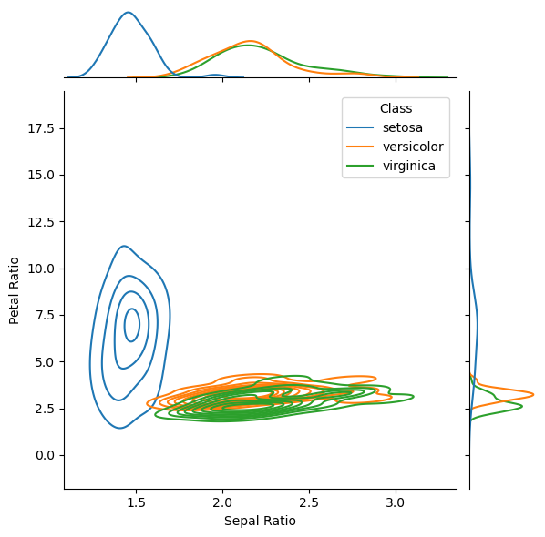

```python
plt2 = sns.jointplot(data=data, x="Sepal Ratio", y="Petal Ratio", hue="Class", kind="kde")
```

```python
# 将数据建模为高斯混合
# 每个高斯生成一个聚类
# 对于每个聚类，估计均值和协方差
colors = ['red', 'blue']
from sklearn import mixture
R = np.stack([sepal_ratio, petal_ratio], axis=1)
# 每个sklearn模型都支持fit方法。在这种情况下，拟合包括估计n=2个组件的均值和协方差。
# 但通常我们不知道类别，所以我们不知道如何选择n_components。这称为模型选择。
gmm = mixture.GaussianMixture(n_components=2,  covariance_type='full')
gmm.fit(R)

labels = gmm.predict(R)
```

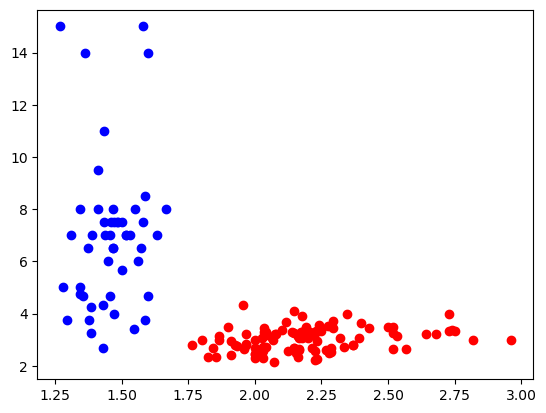

```python
for i in np.unique(labels):
    plt.scatter(sepal_ratio[labels==i], petal_ratio[labels==i], c=colors[i], label=i)
```

```python
# 通过 gmm.means_ 可以提取出每个高斯成分的均值
print(gmm.means_)
```

```
[[2.1906731  3.02559636]
 [1.45993634 6.98743993]]
```